# LAB4

```python
import pandas as pd
from sklearn.preprocessing import StandardScaler
from sklearn.model_selection import train_test_split
import numpy as np
import matplotlib.pyplot as plt
import seaborn as sns
from sklearn.neighbors import KNeighborsClassifier
from sklearn.metrics import accuracy_score, precision_score, recall_score, f1_score, confusion_matrix, roc_curve, auc
```

### Task 1: Data Preparation

```python
# Load the dataset
df = pd.read_csv('/content/brca.csv')

# Display the first 5 rows
print("First 5 rows of the dataset:")
display(df.head())
```

```
First 5 rows of the dataset:
```

|  | Unnamed: 0 | x.radius_mean | x.texture_mean | x.perimeter_mean | x.area_mean | x.smoothness_mean | x.compactness_mean | x.concavity_mean | x.concave_pts_mean | x.symmetry_mean | ... | x.texture_worst | x.perimeter_worst | x.area_worst | x.smoothness_worst | x.compactness_worst | x.concavity_worst | x.concave_pts_worst | x.symmetry_worst | x.fractal_dim_worst | y |
| --- | --- | --- | --- | --- | --- | --- | --- | --- | --- | --- | --- | --- | --- | --- | --- | --- | --- | --- | --- | --- | --- |
| 0 | 1 | 13.540 | 14.36 | 87.46 | 566.3 | 0.09779 | 0.08129 | 0.06664 | 0.047810 | 0.1885 | ... | 19.26 | 99.70 | 711.2 | 0.14400 | 0.17730 | 0.23900 | 0.12880 | 0.2977 | 0.07259 | B |
| 1 | 2 | 13.080 | 15.71 | 85.63 | 520.0 | 0.10750 | 0.12700 | 0.04568 | 0.031100 | 0.1967 | ... | 20.49 | 96.09 | 630.5 | 0.13120 | 0.27760 | 0.18900 | 0.07283 | 0.3184 | 0.08183 | B |
| 2 | 3 | 9.504 | 12.44 | 60.34 | 273.9 | 0.10240 | 0.06492 | 0.02956 | 0.020760 | 0.1815 | ... | 15.66 | 65.13 | 314.9 | 0.13240 | 0.11480 | 0.08867 | 0.06227 | 0.2450 | 0.07773 | B |
| 3 | 4 | 13.030 | 18.42 | 82.61 | 523.8 | 0.08983 | 0.03766 | 0.02562 | 0.029230 | 0.1467 | ... | 22.81 | 84.46 | 545.9 | 0.09701 | 0.04619 | 0.04833 | 0.05013 | 0.1987 | 0.06169 | B |
| 4 | 5 | 8.196 | 16.84 | 51.71 | 201.9 | 0.08600 | 0.05943 | 0.01588 | 0.005917 | 0.1769 | ... | 21.96 | 57.26 | 242.2 | 0.12970 | 0.13570 | 0.06880 | 0.02564 | 0.3105 | 0.07409 | B |

5 rows × 32 columns

#### Data Inspection

```python
# Explore the structure of the dataset
print("\nDataset Info:")
df.info()

# Check for missing values
print("\nMissing values per column:")
display(df.isnull().sum())

# Check for duplicate rows
print("\nNumber of duplicate rows:", df.duplicated().sum())
```

```
Dataset Info:
<class 'pandas.core.frame.DataFrame'>
RangeIndex: 569 entries, 0 to 568
Data columns (total 32 columns):
 #   Column               Non-Null Count  Dtype
---  ------               --------------  -----
 0   Unnamed: 0           569 non-null    int64
 1   x.radius_mean        569 non-null    float64
 2   x.texture_mean       569 non-null    float64
 3   x.perimeter_mean     569 non-null    float64
 4   x.area_mean          569 non-null    float64
 5   x.smoothness_mean    569 non-null    float64
 6   x.compactness_mean   569 non-null    float64
 7   x.concavity_mean     569 non-null    float64
 8   x.concave_pts_mean   569 non-null    float64
```

[output cut: 27 more lines]

|  | 0 |
| --- | --- |
| Unnamed: 0 | 0 |
| x.radius_mean | 0 |
| x.texture_mean | 0 |
| x.perimeter_mean | 0 |
| x.area_mean | 0 |
| x.smoothness_mean | 0 |
| x.compactness_mean | 0 |
| x.concavity_mean | 0 |
| x.concave_pts_mean | 0 |
| x.symmetry_mean | 0 |
| x.fractal_dim_mean | 0 |
| x.radius_se | 0 |
| x.texture_se | 0 |
| x.perimeter_se | 0 |
| x.area_se | 0 |
| x.smoothness_se | 0 |
| x.compactness_se | 0 |
| x.concavity_se | 0 |
| x.concave_pts_se | 0 |
| x.symmetry_se | 0 |
| x.fractal_dim_se | 0 |
| x.radius_worst | 0 |
| x.texture_worst | 0 |
| x.perimeter_worst | 0 |
| x.area_worst | 0 |
| x.smoothness_worst | 0 |
| x.compactness_worst | 0 |
| x.concavity_worst | 0 |
| x.concave_pts_worst | 0 |
| x.symmetry_worst | 0 |
| x.fractal_dim_worst | 0 |
| y | 0 |

**dtype:** int64

```
Number of duplicate rows: 0
```

#### Data Cleaning and Encoding

The `Unnamed: 0` column is an ID and not useful for classification. The target variable `y` needs to be renamed to `diagnosis` and encoded numerically (M=Malignant=1, B=Benign=0).

```python
# Drop the 'Unnamed: 0' column
df = df.drop(columns=['Unnamed: 0'])

# Rename the target variable 'y' to 'diagnosis'
df = df.rename(columns={'y': 'diagnosis'})

# Encode the target variable 'diagnosis' (M=1, B=0)
df['diagnosis'] = df['diagnosis'].map({'M': 1, 'B': 0})

# Verify the changes
print("\nDataset after cleaning and encoding:")
display(df.head())
print("\nValue counts for 'diagnosis':")
display(df['diagnosis'].value_counts())
```

```
Dataset after cleaning and encoding:
```

|  | x.radius_mean | x.texture_mean | x.perimeter_mean | x.area_mean | x.smoothness_mean | x.compactness_mean | x.concavity_mean | x.concave_pts_mean | x.symmetry_mean | x.fractal_dim_mean | ... | x.texture_worst | x.perimeter_worst | x.area_worst | x.smoothness_worst | x.compactness_worst | x.concavity_worst | x.concave_pts_worst | x.symmetry_worst | x.fractal_dim_worst | diagnosis |
| --- | --- | --- | --- | --- | --- | --- | --- | --- | --- | --- | --- | --- | --- | --- | --- | --- | --- | --- | --- | --- | --- |
| 0 | 13.540 | 14.36 | 87.46 | 566.3 | 0.09779 | 0.08129 | 0.06664 | 0.047810 | 0.1885 | 0.05766 | ... | 19.26 | 99.70 | 711.2 | 0.14400 | 0.17730 | 0.23900 | 0.12880 | 0.2977 | 0.07259 | 0 |
| 1 | 13.080 | 15.71 | 85.63 | 520.0 | 0.10750 | 0.12700 | 0.04568 | 0.031100 | 0.1967 | 0.06811 | ... | 20.49 | 96.09 | 630.5 | 0.13120 | 0.27760 | 0.18900 | 0.07283 | 0.3184 | 0.08183 | 0 |
| 2 | 9.504 | 12.44 | 60.34 | 273.9 | 0.10240 | 0.06492 | 0.02956 | 0.020760 | 0.1815 | 0.06905 | ... | 15.66 | 65.13 | 314.9 | 0.13240 | 0.11480 | 0.08867 | 0.06227 | 0.2450 | 0.07773 | 0 |
| 3 | 13.030 | 18.42 | 82.61 | 523.8 | 0.08983 | 0.03766 | 0.02562 | 0.029230 | 0.1467 | 0.05863 | ... | 22.81 | 84.46 | 545.9 | 0.09701 | 0.04619 | 0.04833 | 0.05013 | 0.1987 | 0.06169 | 0 |
| 4 | 8.196 | 16.84 | 51.71 | 201.9 | 0.08600 | 0.05943 | 0.01588 | 0.005917 | 0.1769 | 0.06503 | ... | 21.96 | 57.26 | 242.2 | 0.12970 | 0.13570 | 0.06880 | 0.02564 | 0.3105 | 0.07409 | 0 |

5 rows × 31 columns

```
Value counts for 'diagnosis':
```

| diagnosis | count |
| --- | --- |
| 0 | 357 |
| 1 | 212 |

**dtype:** int64

#### Feature Scaling

KNN is a distance-based algorithm, so feature scaling is essential to prevent features with larger ranges from dominating distance calculations. `StandardScaler` will normalize features to a mean of 0 and standard deviation of 1.

```python
# Separate features (X) and target (y)
X = df.drop('diagnosis', axis=1)
y = df['diagnosis']

# Apply StandardScaler
scaler = StandardScaler()
X_scaled = scaler.fit_transform(X)

# Convert scaled features back to a DataFrame for inspection
X_scaled_df = pd.DataFrame(X_scaled, columns=X.columns)

print("\nFirst 5 rows of scaled features:")
display(X_scaled_df.head())
print("\nDescriptive statistics of scaled features (mean ~0, std dev ~1):")
display(X_scaled_df.describe())
```

```
First 5 rows of scaled features:
```

|  | x.radius_mean | x.texture_mean | x.perimeter_mean | x.area_mean | x.smoothness_mean | x.compactness_mean | x.concavity_mean | x.concave_pts_mean | x.symmetry_mean | x.fractal_dim_mean | ... | x.radius_worst | x.texture_worst | x.perimeter_worst | x.area_worst | x.smoothness_worst | x.compactness_worst | x.concavity_worst | x.concave_pts_worst | x.symmetry_worst | x.fractal_dim_worst |
| --- | --- | --- | --- | --- | --- | --- | --- | --- | --- | --- | --- | --- | --- | --- | --- | --- | --- | --- | --- | --- | --- |
| 0 | -0.166799 | -1.147162 | -0.185728 | -0.251957 | 0.101747 | -0.436850 | -0.278210 | -0.028609 | 0.267911 | -0.728310 | ... | -0.240048 | -1.045005 | -0.225217 | -0.297761 | 0.509873 | -0.489605 | -0.159223 | 0.216123 | 0.123347 | -0.629292 |
| 1 | -0.297446 | -0.833008 | -0.261106 | -0.383638 | 0.792763 | 0.429422 | -0.541362 | -0.459627 | 0.567289 | 0.753087 | ... | -0.366368 | -0.844707 | -0.332744 | -0.439624 | -0.051226 | 0.148443 | -0.399099 | -0.636110 | 0.458227 | -0.117250 |
| 2 | -1.313080 | -1.593959 | -1.302806 | -1.083572 | 0.429819 | -0.747086 | -0.743748 | -0.726337 | 0.012345 | 0.886341 | ... | -1.250611 | -1.631243 | -1.254913 | -0.994422 | 0.001377 | -0.887193 | -0.880434 | -0.796903 | -0.729224 | -0.344455 |
| 3 | -0.311646 | -0.202373 | -0.385500 | -0.372831 | -0.464730 | -1.263703 | -0.793214 | -0.507861 | -1.258183 | -0.590802 | ... | -0.614867 | -0.466909 | -0.679153 | -0.588344 | -1.549975 | -1.323648 | -1.073966 | -0.981753 | -1.478256 | -1.233324 |
| 4 | -1.684571 | -0.570050 | -1.658278 | -1.288347 | -0.737294 | -0.851130 | -0.915500 | -1.109197 | -0.155598 | 0.316465 | ... | -1.512777 | -0.605327 | -1.489328 | -1.122222 | -0.116980 | -0.754239 | -0.975761 | -1.354653 | 0.330422 | -0.546168 |

5 rows × 30 columns

```
Descriptive statistics of scaled features (mean ~0, std dev ~1):
```

|  | x.radius_mean | x.texture_mean | x.perimeter_mean | x.area_mean | x.smoothness_mean | x.compactness_mean | x.concavity_mean | x.concave_pts_mean | x.symmetry_mean | x.fractal_dim_mean | ... | x.radius_worst | x.texture_worst | x.perimeter_worst | x.area_worst | x.smoothness_worst | x.compactness_worst | x.concavity_worst | x.concave_pts_worst | x.symmetry_worst | x.fractal_dim_worst |
| --- | --- | --- | --- | --- | --- | --- | --- | --- | --- | --- | --- | --- | --- | --- | --- | --- | --- | --- | --- | --- | --- |
| count | 5.690000e+02 | 5.690000e+02 | 5.690000e+02 | 5.690000e+02 | 5.690000e+02 | 5.690000e+02 | 569.000000 | 5.690000e+02 | 5.690000e+02 | 5.690000e+02 | ... | 5.690000e+02 | 5.690000e+02 | 5.690000e+02 | 5.690000e+02 | 5.690000e+02 | 569.000000 | 5.690000e+02 | 5.690000e+02 | 5.690000e+02 | 5.690000e+02 |
| mean | -1.998011e-16 | -7.492542e-16 | -9.990056e-17 | -1.998011e-16 | 1.498508e-16 | 1.998011e-16 | 0.000000 | 9.990056e-17 | 1.498508e-16 | 4.745277e-16 | ... | -9.990056e-17 | 2.497514e-17 | 9.990056e-17 | -1.998011e-16 | -1.398608e-15 | 0.000000 | 9.990056e-17 | 2.997017e-16 | 2.497514e-16 | 1.998011e-16 |
| std | 1.000880e+00 | 1.000880e+00 | 1.000880e+00 | 1.000880e+00 | 1.000880e+00 | 1.000880e+00 | 1.000880 | 1.000880e+00 | 1.000880e+00 | 1.000880e+00 | ... | 1.000880e+00 | 1.000880e+00 | 1.000880e+00 | 1.000880e+00 | 1.000880e+00 | 1.000880 | 1.000880e+00 | 1.000880e+00 | 1.000880e+00 | 1.000880e+00 |
| min | -2.029648e+00 | -2.229249e+00 | -1.984504e+00 | -1.454443e+00 | -3.112085e+00 | -1.610136e+00 | -1.114873 | -1.261820e+00 | -2.744117e+00 | -1.819865e+00 | ... | -1.726901e+00 | -2.223994e+00 | -1.693361e+00 | -1.222423e+00 | -2.682695e+00 | -1.443878 | -1.305831e+00 | -1.745063e+00 | -2.160960e+00 | -1.601839e+00 |
| 25% | -6.893853e-01 | -7.259631e-01 | -6.919555e-01 | -6.671955e-01 | -7.109628e-01 | -7.470860e-01 | -0.743748 | -7.379438e-01 | -7.032397e-01 | -7.226392e-01 | ... | -6.749213e-01 | -7.486293e-01 | -6.895783e-01 | -6.421359e-01 | -6.912304e-01 | -0.681083 | -7.565142e-01 | -7.563999e-01 | -6.418637e-01 | -6.919118e-01 |
| 50% | -2.150816e-01 | -1.046362e-01 | -2.359800e-01 | -2.951869e-01 | -3.489108e-02 | -2.219405e-01 | -0.342240 | -3.977212e-01 | -7.162650e-02 | -1.782793e-01 | ... | -2.690395e-01 | -4.351564e-02 | -2.859802e-01 | -3.411812e-01 | -4.684277e-02 | -0.269501 | -2.182321e-01 | -2.234689e-01 | -1.274095e-01 | -2.164441e-01 |
| 75% | 4.693926e-01 | 5.841756e-01 | 4.996769e-01 | 3.635073e-01 | 6.361990e-01 | 4.938569e-01 | 0.526062 | 6.469351e-01 | 5.307792e-01 | 4.709834e-01 | ... | 5.220158e-01 | 6.583411e-01 | 5.402790e-01 | 3.575891e-01 | 5.975448e-01 | 0.539669 | 5.311411e-01 | 7.125100e-01 | 4.501382e-01 | 4.507624e-01 |
| max | 3.971288e+00 | 4.651889e+00 | 3.976130e+00 | 5.250529e+00 | 4.770911e+00 | 4.568425e+00 | 4.243589 | 3.927930e+00 | 4.484751e+00 | 4.910919e+00 | ... | 4.094189e+00 | 3.885905e+00 | 4.287337e+00 | 5.930172e+00 | 3.955374e+00 | 5.112877 | 4.700669e+00 | 2.685877e+00 | 6.046041e+00 | 6.846856e+00 |

8 rows × 30 columns

### Task 2: Train-Test Split Analysis

#### 2.1 Split dataset into training and testing sets (80:20)

```python
# 80:20 split
X_train_80_20, X_test_80_20, y_train_80_20, y_test_80_20 = train_test_split(X_scaled, y, test_size=0.20, random_state=42)

print(f"80:20 Split: ")
print(f"  Training features shape: {X_train_80_20.shape}")
print(f"  Testing features shape: {X_test_80_20.shape}")
print(f"  Training target shape: {y_train_80_20.shape}")
print(f"  Testing target shape: {y_test_80_20.shape}")
```

```
80:20 Split:
  Training features shape: (455, 30)
  Testing features shape: (114, 30)
  Training target shape: (455,)
  Testing target shape: (114,)
```

#### 2.2 Evaluate different train-test split ratios (70:30 and 90:10)

```python
# 70:30 split
X_train_70_30, X_test_70_30, y_train_70_30, y_test_70_30 = train_test_split(X_scaled, y, test_size=0.30, random_state=42)

print(f"\n70:30 Split: ")
print(f"  Training features shape: {X_train_70_30.shape}")
print(f"  Testing features shape: {X_test_70_30.shape}")
print(f"  Training target shape: {y_train_70_30.shape}")
print(f"  Testing target shape: {y_test_70_30.shape}")

# 90:10 split
X_train_90_10, X_test_90_10, y_train_90_10, y_test_90_10 = train_test_split(X_scaled, y, test_size=0.10, random_state=42)

print(f"\n90:10 Split: ")
print(f"  Training features shape: {X_train_90_10.shape}")
print(f"  Testing features shape: {X_test_90_10.shape}")
print(f"  Training target shape: {y_train_90_10.shape}")
print(f"  Testing target shape: {y_test_90_10.shape}")
```

```
70:30 Split:
  Training features shape: (398, 30)
  Testing features shape: (171, 30)
  Training target shape: (398,)
  Testing target shape: (171,)

90:10 Split:
  Training features shape: (512, 30)
  Testing features shape: (57, 30)
  Training target shape: (512,)
  Testing target shape: (57,)
```

#### 2.3 Evaluate KNN (K=5) for each split and analyze variations

```python
def evaluate_knn_split(X_train, X_test, y_train, y_test, split_name):
    knn = KNeighborsClassifier(n_neighbors=5) # Using K=5 as a placeholder
    knn.fit(X_train, y_train)
    y_pred = knn.predict(X_test)
    accuracy = accuracy_score(y_test, y_pred)
    print(f"\n{split_name} Split Accuracy (K=5): {accuracy:.4f}")
    return accuracy

accuracy_80_20 = evaluate_knn_split(X_train_80_20, X_test_80_20, y_train_80_20, y_test_80_20, "80:20")
accuracy_70_30 = evaluate_knn_split(X_train_70_30, X_test_70_30, y_train_70_30, y_test_70_30, "70:30")
accuracy_90_10 = evaluate_knn_split(X_train_90_10, X_test_90_10, y_train_90_10, y_test_90_10, "90:10")

print("\n--- Analysis of Train-Test Split Effects ---")
print(f"Accuracy for 80:20 split: {accuracy_80_20:.4f}")
print(f"Accuracy for 70:30 split: {accuracy_70_30:.4f}")
print(f"Accuracy for 90:10 split: {accuracy_90_10:.4f}")

print("\n**Observations:**")
print("- Different splits can give slightly different accuracies, showing how test set composition matters.")
print("- Smaller test sets (like 90:10) can give less reliable accuracy estimates.")
print("- An 80:20 split often balances enough training data with a reasonable test set size for evaluation.")
```

```
80:20 Split Accuracy (K=5): 0.9298

70:30 Split Accuracy (K=5): 0.9591

90:10 Split Accuracy (K=5): 0.9298

--- Analysis of Train-Test Split Effects ---
Accuracy for 80:20 split: 0.9298
Accuracy for 70:30 split: 0.9591
Accuracy for 90:10 split: 0.9298

**Observations:**
- Different splits can give slightly different accuracies, showing how test set composition matters.
- Smaller test sets (like 90:10) can give less reliable accuracy estimates.
- An 80:20 split often balances enough training data with a reasonable test set size for evaluation.
```

### Task 3: KNN Model with Heuristic K Selection

#### 3.1 Heuristic Method for K Selection

We'll use the $\sqrt{n}$ rule to find an initial K, where `n` is the number of training samples. For binary classification, K should be odd to avoid ties.

```python
# Use the 80:20 split for further analysis
X_train, X_test, y_train, y_test = X_train_80_20, X_test_80_20, y_train_80_20, y_test_80_20

n = X_train.shape[0]
initial_k = int(np.sqrt(n))
print(f"Number of training samples (n): {n}")
print(f"Heuristic initial K (√n): {initial_k}")

# Ensure K is odd
if initial_k % 2 == 0:
    initial_k += 1
print(f"Adjusted initial K (odd): {initial_k}")
```

```
Number of training samples (n): 455
Heuristic initial K (√n): 21
Adjusted initial K (odd): 21
```

#### 3.2 Model Training with Heuristic K and Accuracy Plot

We'll train KNN models with K values around the heuristic K and plot their accuracy to find an optimal K.

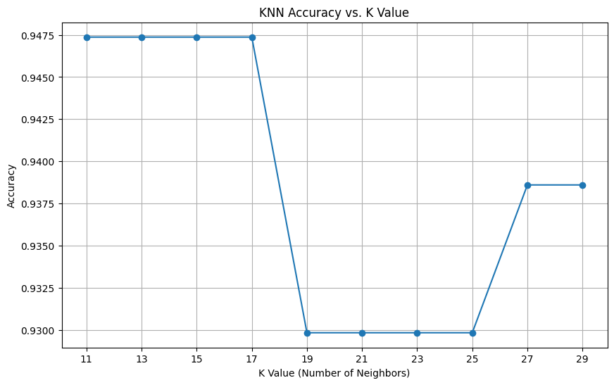

```
Optimal K value based on accuracy plot: 11 with accuracy: 0.9474
**Observation:** This plot helps identify a K value that provides good accuracy without being too sensitive (small K) or too generalized (large K).
```

```python
# Experiment with nearby K values (e.g., K ± 10, ensuring K > 0 and odd)
k_values = [k for k in range(max(1, initial_k - 10), initial_k + 10, 2) if k > 0]

if initial_k not in k_values:
    k_values.append(initial_k)
k_values.sort()

accuracies = []
for k in k_values:
    knn = KNeighborsClassifier(n_neighbors=k)
    knn.fit(X_train, y_train)
    y_pred = knn.predict(X_test)
    accuracies.append(accuracy_score(y_test, y_pred))

# Plot accuracy vs K values
plt.figure(figsize=(10, 6))
plt.plot(k_values, accuracies, marker='o', linestyle='-')
plt.title('KNN Accuracy vs. K Value')
plt.xlabel('K Value (Number of Neighbors)')
plt.ylabel('Accuracy')
plt.xticks(k_values)
plt.grid(True)
plt.show()

# Identify optimal K
optimal_k_index = np.argmax(accuracies)
optimal_k = k_values[optimal_k_index]
print(f"\nOptimal K value based on accuracy plot: {optimal_k} with accuracy: {accuracies[optimal_k_index]:.4f}")
print("**Observation:** This plot helps identify a K value that provides good accuracy without being too sensitive (small K) or too generalized (large K).")
```

#### 3.3 Distance Metrics and Decision Boundary Mapping

KNN uses distance metrics to find neighbors. Euclidean and Manhattan distances are common choices.

##### Explanation of Distance Metrics

- **Euclidean Distance:** The straight-line distance between two points. Best when data features are similar and continuous.
- **Manhattan Distance:** The sum of absolute differences between coordinates (like walking in a city grid). Useful in high dimensions or when features aren't geometrically related.

##### Plotting Decision Boundaries

To visualize decision boundaries for a high-dimensional dataset, we use Principal Component Analysis (PCA) to reduce the data to 2 dimensions.

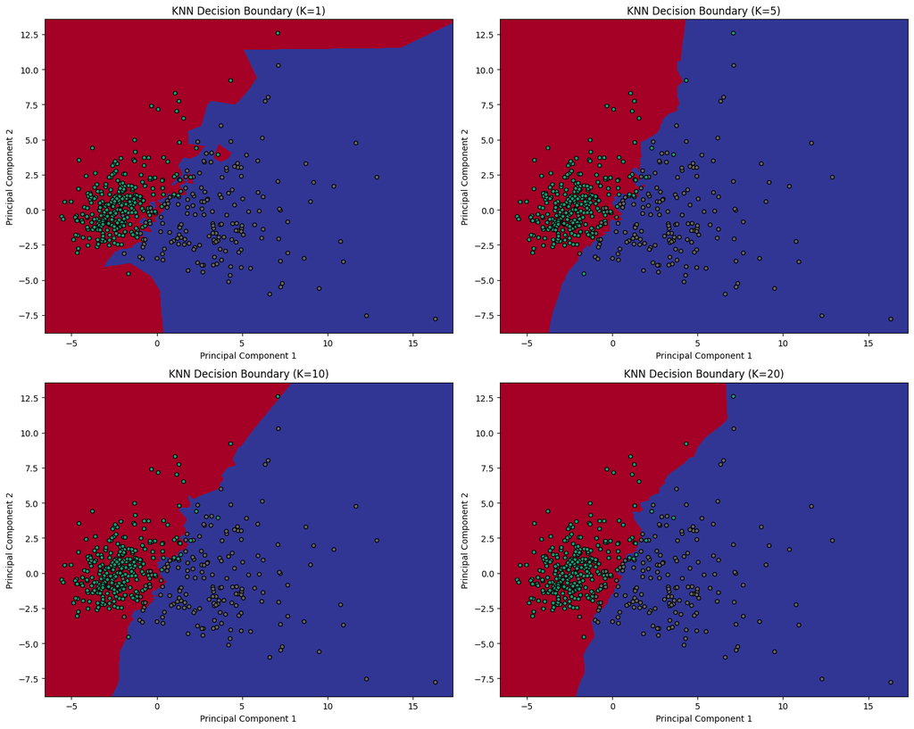

```
**Analysis of Decision Boundary Changes as K Increases:**
- **K = 1:** Very complex boundary, sensitive to noise (overfitting risk).
- **K = 5 (and other small K values):** Smoother boundary, better generalization.
- **K = 10, 20 (and larger K values):** Very smooth boundary, may oversimplify patterns (underfitting risk).
- **General Trend:** Small K = high variance, low bias (overfit). Large K = low variance, high bias (underfit). We aim for a balance.
```

```python
from sklearn.decomposition import PCA

# Reduce dimensions to 2 using PCA for visualization
pca = PCA(n_components=2)
X_pca = pca.fit_transform(X_scaled)

# Split the PCA-transformed data (using the 80:20 split indices)
X_train_pca, X_test_pca, y_train_pca, y_test_pca = train_test_split(X_pca, y, test_size=0.20, random_state=42)

def plot_decision_boundary(X, y, k_value, ax, title):
    h = .02  # step size in the mesh
    knn = KNeighborsClassifier(n_neighbors=k_value)
    knn.fit(X, y)

    # Create color maps
    cmap_light = plt.cm.RdYlBu
    cmap_bold = plt.cm.Dark2

    # Plot the decision boundary
    x_min, x_max = X[:, 0].min() - 1, X[:, 0].max() + 1
    y_min, y_max = X[:, 1].min() - 1, X[:, 1].max() + 1
    xx, yy = np.meshgrid(np.arange(x_min, x_max, h),
                         np.arange(y_min, y_max, h))
    Z = knn.predict(np.c_[xx.ravel(), yy.ravel()])

    # Put the result into a color plot
    Z = Z.reshape(xx.shape)
    ax.pcolormesh(xx, yy, Z, cmap=cmap_light)

    # Plot also the training points
    ax.scatter(X[:, 0], X[:, 1], c=y, cmap=cmap_bold, edgecolor='k', s=20)
    ax.set_xlim(xx.min(), xx.max())
    ax.set_ylim(yy.min(), yy.max())
    ax.set_title(title)
    ax.set_xlabel('Principal Component 1')
    ax.set_ylabel('Principal Component 2')

k_values_to_plot = [1, 5, 10, 20]
fig, axes = plt.subplots(2, 2, figsize=(15, 12))
axes = axes.flatten()

for i, k in enumerate(k_values_to_plot):
    plot_decision_boundary(X_train_pca, y_train_pca, k, axes[i], f'KNN Decision Boundary (K={k})')

plt.tight_layout()
plt.show()

print("\n**Analysis of Decision Boundary Changes as K Increases:**")
print("- **K = 1:** Very complex boundary, sensitive to noise (overfitting risk).")
print("- **K = 5 (and other small K values):** Smoother boundary, better generalization.")
print("- **K = 10, 20 (and larger K values):** Very smooth boundary, may oversimplify patterns (underfitting risk).")
print("- **General Trend:** Small K = high variance, low bias (overfit). Large K = low variance, high bias (underfit). We aim for a balance.")
```

### Task 4: Cross-Validation

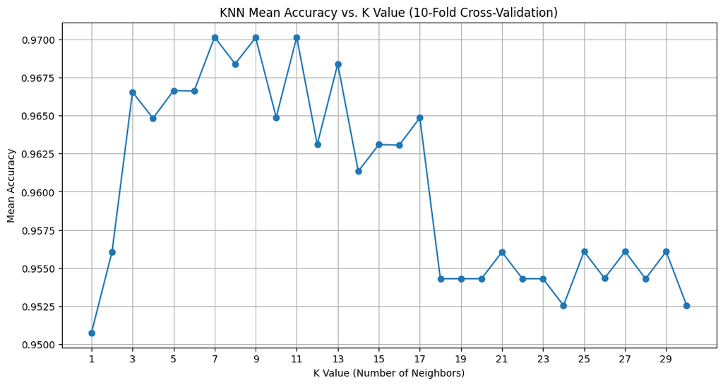

[output not shown]

```python
from sklearn.model_selection import cross_val_score

# Define K values to test
k_range = range(1, 31)

# Store mean accuracy for each K
cv_accuracies = []

# Perform 10-Fold Cross-Validation
num_folds = 10

for k in k_range:
    knn = KNeighborsClassifier(n_neighbors=k)
    scores = cross_val_score(knn, X_scaled, y, cv=num_folds, scoring='accuracy')
    cv_accuracies.append(scores.mean())

# Plot mean accuracy vs K
plt.figure(figsize=(12, 6))
plt.plot(k_range, cv_accuracies, marker='o', linestyle='-')
plt.title('KNN Mean Accuracy vs. K Value (10-Fold Cross-Validation)')
plt.xlabel('K Value (Number of Neighbors)')
plt.ylabel('Mean Accuracy')
plt.xticks(np.arange(1, 31, 2))
plt.grid(True)
plt.show()

# Identify optimal K from cross-validation
optimal_k_cv_index = np.argmax(cv_accuracies)
optimal_k_cv = k_range[optimal_k_cv_index]
print(f"Optimal K value based on 10-Fold Cross-Validation: {optimal_k_cv} with mean accuracy: {cv_accuracies[optimal_k_cv_index]:.4f}")
```

#### Comparison with Train-Test Split Results and Selection of Best K

Let's compare the optimal K found using cross-validation with the one from the train-test split heuristic.

```python
# Re-calculate heuristic K and optimal K from train-test split for direct comparison
# Using the 80:20 split as before
X_train, X_test, y_train, y_test = X_train_80_20, X_test_80_20, y_train_80_20, y_test_80_20

n = X_train.shape[0]
initial_k_heuristic = int(np.sqrt(n))
if initial_k_heuristic % 2 == 0:
    initial_k_heuristic += 1

k_values_tt = [k for k in range(max(1, initial_k_heuristic - 10), initial_k_heuristic + 10, 2) if k > 0]
if initial_k_heuristic not in k_values_tt:
    k_values_tt.append(initial_k_heuristic)
k_values_tt.sort()

accuracies_tt = []
for k in k_values_tt:
    knn = KNeighborsClassifier(n_neighbors=k)
    knn.fit(X_train, y_train)
    y_pred = knn.predict(X_test)
    accuracies_tt.append(accuracy_score(y_test, y_pred))

optimal_k_tt_index = np.argmax(accuracies_tt)
optimal_k_tt = k_values_tt[optimal_k_tt_index]

print(f"Heuristic initial K (adjusted to odd): {initial_k_heuristic}")
print(f"Optimal K from Train-Test Split (80:20) analysis: {optimal_k_tt} with accuracy: {accuracies_tt[optimal_k_tt_index]:.4f}")
print(f"Optimal K from 10-Fold Cross-Validation: {optimal_k_cv} with mean accuracy: {cv_accuracies[optimal_k_cv_index]:.4f}")

print("\n--- Comparison and Selection of Best K ---")
print("**Observations:**")
print("- Cross-validation gives a more reliable K because it tests the model on different data subsets.")
print("- The heuristic K is a good starting point, but validation methods fine-tune it.")

# Select the best K based on cross-validation, as it's more robust
best_k = optimal_k_cv
print(f"\nBased on robust 10-Fold Cross-Validation, we select the best K for our final model: **{best_k}**")
```

[output not shown]

### Task 5: Classification Evaluation

We will evaluate the final KNN model using the `best_k` (from cross-validation) and the 80:20 train-test split.

```
--- Evaluation Metrics for KNN Model with K=11 ---
Accuracy: 0.9474
Precision: 1.0000
Recall: 0.8605
F1 Score: 0.9250

Confusion Matrix:
[[71  0]
 [ 6 37]]
```

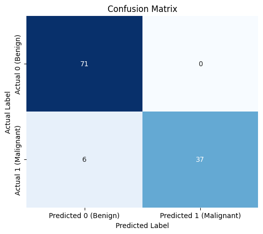

```
ROC AUC Score: 0.9897
```

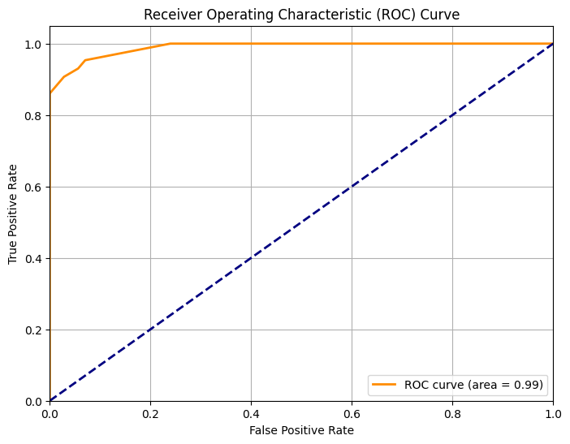

```
--- Interpretation of Evaluation Metrics ---
- **Accuracy:** Overall correct predictions. Can be misleading with imbalanced data.
- **Precision:** How many positive predictions were actually correct. Important when false positives are costly.
- **Recall (Sensitivity):** How many actual positive cases were correctly identified. Critical when false negatives are costly (e.g., missing cancer).
- **F1 Score:** Balances Precision and Recall, good for imbalanced datasets.
- **Confusion Matrix:** Shows counts of True Positives, True Negatives, False Positives, False Negatives.
- **ROC Curve & AUC:** Measures model's ability to distinguish classes across different thresholds. Higher AUC means better performance.
```

```python
# Using the best_k and the 80:20 train-test split
X_train, X_test, y_train, y_test = X_train_80_20, X_test_80_20, y_train_80_20, y_test_80_20

# Initialize and train the KNN classifier with the best K
final_knn_model = KNeighborsClassifier(n_neighbors=best_k)
final_knn_model.fit(X_train, y_train)

# Make predictions on the test set
y_pred = final_knn_model.predict(X_test)
y_proba = final_knn_model.predict_proba(X_test)[:, 1] # Probabilities for ROC AUC

print(f"--- Evaluation Metrics for KNN Model with K={best_k} ---")

# Accuracy
accuracy = accuracy_score(y_test, y_pred)
print(f"Accuracy: {accuracy:.4f}")

# Precision
precision = precision_score(y_test, y_pred)
print(f"Precision: {precision:.4f}")

# Recall
recall = recall_score(y_test, y_pred)
print(f"Recall: {recall:.4f}")

# F1 Score
f1 = f1_score(y_test, y_pred)
print(f"F1 Score: {f1:.4f}")

# Confusion Matrix
conf_matrix = confusion_matrix(y_test, y_pred)
print("\nConfusion Matrix:")
print(conf_matrix)

# Plot Confusion Matrix
plt.figure(figsize=(6, 5))
sns.heatmap(conf_matrix, annot=True, fmt='d', cmap='Blues', cbar=False,
            xticklabels=['Predicted 0 (Benign)', 'Predicted 1 (Malignant)'],
            yticklabels=['Actual 0 (Benign)', 'Actual 1 (Malignant)'])
plt.title('Confusion Matrix')
plt.ylabel('Actual Label')
plt.xlabel('Predicted Label')
plt.show()

# ROC Curve and AUC Score
fpr, tpr, thresholds = roc_curve(y_test, y_proba)
roc_auc = roc_auc_score(y_test, y_proba)

print(f"\nROC AUC Score: {roc_auc:.4f}")

# Plot ROC Curve
plt.figure(figsize=(8, 6))
plt.plot(fpr, tpr, color='darkorange', lw=2, label=f'ROC curve (area = {roc_auc:.2f})')
plt.plot([0, 1], [0, 1], color='navy', lw=2, linestyle='--')
plt.xlim([0.0, 1.0])
plt.ylim([0.0, 1.05])
plt.xlabel('False Positive Rate')
plt.ylabel('True Positive Rate')
plt.title('Receiver Operating Characteristic (ROC) Curve')
plt.legend(loc="lower right")
plt.grid(True)
plt.show()

print("\n--- Interpretation of Evaluation Metrics ---")
print("- **Accuracy:** Overall correct predictions. Can be misleading with imbalanced data.")
print("- **Precision:** How many positive predictions were actually correct. Important when false positives are costly.")
print("- **Recall (Sensitivity):** How many actual positive cases were correctly identified. Critical when false negatives are costly (e.g., missing cancer).")
print("- **F1 Score:** Balances Precision and Recall, good for imbalanced datasets.")
print("- **Confusion Matrix:** Shows counts of True Positives, True Negatives, False Positives, False Negatives.")
print("- **ROC Curve & AUC:** Measures model's ability to distinguish classes across different thresholds. Higher AUC means better performance.")
```

### Task 6: Comparative Study with Regression (Lab 3 Integration)

This section provides a comprehensive comparison between classification evaluation metrics (from this lab) and regression evaluation metrics (from Lab 3).

```python
# Regression metrics from Lab 3
regression_metrics = {
    'MAE': 0.699596887791859,
    'RMSE': 1.7308781726135083,
    'R2 Score': -0.5804993489697676
}

classification_metrics = {
    'Accuracy': accuracy,
    'Precision': precision,
    'Recall': recall,
    'F1 Score': f1,
    'ROC AUC': roc_auc
}

print("\n--- Numerical Comparison ---")
print("Classification Metrics (Current Lab):")
for name, value in classification_metrics.items():
    print(f"{name}: {value:.4f}")

print("\nRegression Metrics (Lab 3):")
for name, value in regression_metrics.items():
    print(f"{name}: {value:.4f}")

print("\nQuantitative Comparison:")
print("Regression metrics measure prediction errors for continuous values, while classification metrics evaluate categorical prediction correctness.")
print(f"- R² Score (Regression): {regression_metrics['R2 Score']:.4f} vs Accuracy (Classification): {classification_metrics['Accuracy']:.4f}")
print(f"- RMSE (Regression): {regression_metrics['RMSE']:.4f} vs F1 Score (Classification): {classification_metrics['F1 Score']:.4f}")
print(f"- MAE (Regression): {regression_metrics['MAE']:.4f} vs Confusion Matrix based metrics (Accuracy/Precision/Recall/F1).")
```

```
--- Numerical Comparison ---
Classification Metrics (Current Lab):
Accuracy: 0.9474
Precision: 1.0000
Recall: 0.8605
F1 Score: 0.9250
ROC AUC: 0.9897

Regression Metrics (Lab 3):
MAE: 0.6996
RMSE: 1.7309
R2 Score: -0.5805

Quantitative Comparison:
Regression metrics measure prediction errors for continuous values, while classification metrics evaluate categorical prediction correctness.
- R² Score (Regression): -0.5805 vs Accuracy (Classification): 0.9474
- RMSE (Regression): 1.7309 vs F1 Score (Classification): 0.9250
- MAE (Regression): 0.6996 vs Confusion Matrix based metrics (Accuracy/Precision/Recall/F1).
```

#### Differences between Error-based Evaluation (Regression) and Decision-based Evaluation (Classification)

**Error-based Evaluation (Regression Metrics)**

- **Purpose:** Measures the magnitude of the difference between predicted continuous values and actual continuous values. It quantifies 'how wrong' the prediction was.
- **Focus:** Continuous output, prediction of numerical values.
- **Examples:** Mean Absolute Error (MAE), Mean Squared Error (MSE), Root Mean Squared Error (RMSE), R² Score.
- **Logic:** These metrics penalize deviations from the true value. A prediction of 10.1 when the true value is 10.0 is a smaller error than a prediction of 15.0, and the metrics reflect this graduated error.

**Decision-based Evaluation (Classification Metrics)**

- **Purpose:** Measures the correctness of discrete class predictions. It quantifies whether the model made the 'right call' regarding the class label.
- **Focus:** Categorical output, prediction of class labels.
- **Examples:** Accuracy, Precision, Recall, F1 Score, Confusion Matrix, ROC-AUC.
- **Logic:** These metrics typically consider a prediction as either entirely right or entirely wrong, based on the assigned class. The severity of 'wrong' can be nuanced (e.g., False Positive vs. False Negative), but the core idea is about correct categorization, not the magnitude of a numerical deviation.

#### Comparison of Specific Metrics

**1. R² Score (Regression) vs Accuracy (Classification)**

- **R² Score:**
  - **What it measures:** The proportion of the variance in the dependent variable that is predictable from the independent variables. It indicates how well the regression model fits the observed data. A higher R² (closer to 1) means a better fit.
  - **Context:** Used when predicting a continuous numerical value. It tells us how much of the variability in the target can be explained by the model.
- **Accuracy:**
  - **What it measures:** The proportion of total predictions that were correct (True Positives + True Negatives) out of all predictions. It indicates the overall correctness of the model's classifications.
  - **Context:** Used when predicting a discrete class label. It tells us how often the model is right about the class.
- **Difference:** R² measures the goodness of fit for *continuous* predictions, focusing on explained variance. Accuracy measures the proportion of *correct classifications* for discrete outcomes. They are fundamentally different because one deals with numerical 'closeness' and the other with categorical 'correctness'.

**2. RMSE (Regression) vs F1 Score (Classification)**

- **RMSE (Root Mean Squared Error):**
  - **What it measures:** The square root of the average of the squared differences between predicted and actual values. It represents the standard deviation of the residuals (prediction errors). It gives a relatively high weight to large errors.
  - **Context:** A common metric for regression, giving an idea of the typical magnitude of prediction errors in the same units as the target variable. Lower RMSE is better.
- **F1 Score:**
  - **What it measures:** The harmonic mean of Precision and Recall. It provides a single metric that balances both false positives and false negatives, especially useful in imbalanced classification datasets.
  - **Context:** Used in classification, particularly when classes are imbalanced or when both false positives and false negatives are important. A higher F1 score (closer to 1) indicates better performance.
- **Difference:** RMSE quantifies the average magnitude of numerical *prediction errors*. F1 Score evaluates the harmonic mean of precision and recall for *class predictions*, balancing different types of classification errors. One is about numerical deviation, the other about classification quality (specifically balancing completeness and exactness).

**3. MAE (Regression) vs Confusion Matrix (Classification)**

- **MAE (Mean Absolute Error):**
  - **What it measures:** The average of the absolute differences between predicted and actual values. It is less sensitive to outliers than MSE/RMSE.
  - **Context:** Another common regression metric, giving the average absolute magnitude of the prediction errors. Lower MAE is better.
- **Confusion Matrix:**
  - **What it measures:** A table summarizing the performance of a classification model, showing counts of: True Positives (TP), True Negatives (TN), False Positives (FP), and False Negatives (FN).
  - **Context:** It's not a single metric but a foundational tool for understanding where a classification model succeeds and fails. It allows calculation of various classification metrics like Accuracy, Precision, Recall, etc.
- **Difference:** MAE provides a single, average value of numerical *prediction error*. The Confusion Matrix provides a *detailed breakdown* of all possible outcomes for *class predictions*, showing the counts of correct and incorrect classifications across different classes. The Confusion Matrix is more informative about the *types* of errors (e.g., misclassifying malignant as benign vs. benign as malignant) whereas MAE only gives an aggregated error magnitude for numerical predictions.

#### Differences in Evaluation Logic for Continuous Prediction Tasks vs. Classification Tasks

- **Continuous Prediction Tasks (Regression):**
  - **Logic:** The primary goal is to minimize the difference between the predicted numerical value and the actual numerical value. The 'closer' the prediction, the better. Errors are often treated as continuous, with larger deviations incurring larger penalties. Evaluation often focuses on the distribution of errors and the model's ability to capture trends and magnitudes.
  - **Example:** Predicting house prices. Being off by $10,000 is generally better than being off by $100,000, and regression metrics reflect this gradient.
- **Classification Tasks:**
  - **Logic:** The primary goal is to assign the correct discrete category or label. The 'correctness' is binary – either the prediction is right, or it's wrong. However, the *cost* of different types of errors (False Positives vs. False Negatives) can vary significantly depending on the application (e.g., medical diagnosis vs. spam detection). Evaluation often focuses on counts of correct/incorrect assignments, and the balance between different types of errors.
  - **Example:** Predicting whether an email is spam or not. There's no 'partially spam' here. The concern might be more about not classifying a legitimate email as spam (False Positive) than letting a few spam emails slip through (False Negative).

### Task 7: Analytical Questions

#### 1. Why is KNN called a lazy learning algorithm?

KNN is "lazy" because it doesn't learn a model during training; it just stores the data. Prediction only happens when new data comes in, by looking up the nearest neighbors.

#### 2. Why is feature scaling required in KNN?

Scaling is vital for KNN because it's distance-based. Without it, features with larger numerical ranges would unfairly dominate the distance calculations, skewing results.

#### 3. Explain heuristic K selection using $\sqrt{n}$ rule.

The $\sqrt{n}$ rule (where `n` is data points) gives a starting K value to balance overfitting (small K) and underfitting (large K). For binary classification, an odd K is preferred to avoid ties.

#### 4. Why is cross-validation more reliable than a single train-test split?

Cross-validation is more robust because it averages results over multiple data splits, giving a more stable and less biased estimate of performance compared to a single, potentially lucky or unlucky, split.

#### 5. How does K affect bias-variance trade-off?

- **Small K:** Low bias (complex model), high variance (sensitive to noise/overfit).
- **Large K:** High bias (simple model), low variance (less sensitive to noise/underfit).

Optimal K balances these to generalize well.

#### 6. Why is recall more important than accuracy in cancer prediction?

Recall is crucial in cancer prediction because a **false negative** (missing a cancer case) has far more severe consequences than a false positive. High recall ensures fewer actual cases are missed, prioritizing patient safety.

#### 7. What is the limitation of very large K values?

Very large K values lead to **underfitting**. The model becomes too general, averaging over too many diverse neighbors and missing important local patterns, making it overly simplistic and less accurate.

### Expected Outcome and Conclusion

In summary, the KNN model was effectively implemented and evaluated, demonstrating its potential for accurate breast cancer diagnosis while highlighting crucial considerations for model tuning and evaluation.